# Visualizing OPUS binary files and DPT files in R

Adrianne Seiden

2025-08-14

# Reading OPUS files

[source](https://spectral-cockpit.github.io/opusreader2/articles/opusreader2_introduction.html)

This code is modified from the original OPUSreader2 documentation vignettes/opusreader2_introduction.Rmd by Philip Baumann and Thomas Knecht. It reads OPUS binary files and extracts metadata and absorbance data, which can then be plotted.

## Plots & Metadata

The main function, `read_opus()`, reads one or more OPUS files and returns a nested list of class `list_opusreader2`. Each list contains both the spectral data and metadata for each file. The `dsn` argument is the data source name. It can be a character vector of folder paths (to read files recursively) or specific OPUS file paths. Start by testing the read_opus function on your corrected spectra folder, and saving the output of the first file.

```r
#load opusreader2 from github.com/spectral-cockpit
library(opusreader2)

#save the path to your corrected spectra
# # Mac path
# corr_spectra <- "/Users/adrianneseiden/Library/CloudStorage/Box-Box/Salk Institute Project/AKS Salk files/Adrianne_FTIRdata/Corrected_files" # nolint
#  # Windows path
# corr_spectra <- "C:/Users/adria/Box/Box-Box/Salk Institute Project/AKS Salk files/Adrianne_FTIRdata/Corrected_files" # nolint
# Relative path
corr_spectra <- "../Adrianne_FTIRdata/Corrected_files"

#save the data from your corrected files as 'data_test'
data_test <- read_opus(dsn = corr_spectra)
#check the names of the list
names(data_test)
>  [1] "DRIFTS_pot001_13Cwheat_wk0_root_250725_corr.0"
>  [2] "DRIFTS_pot030_13Csoy_wk10_root_250725_corr.0"
>  [3] "DRIFTS_pot032_13Cwheat_wk0_root_250725_corr.0"
>  [4] "DRIFTS_pot047_13Crice_wk0_root_250725_corr.0"
>  [5] "DRIFTS_pot053_13Cwheat_wk10_root_250725_corr.0"
>  [6] "DRIFTS_pot055_13Crice_wk10_root_250725_corr.0"
>  [7] "DRIFTS_pot055qmark_13Crice_wk10_root_250725_corr.0"
>  [8] "DRIFTS_pot062_13Csoy_wk0_root_250725_corr.0"
>  [9] "DRIFTS_pot079_13Crice_wk0_root_250725_corr.0"
> [10] "DRIFTS_pot080_13Csoy_wk10_root_250725_corr.0"
> [11] "DRIFTS_pot094_13Csoy_wk10_root_250725_corr.0"
> [12] "DRIFTS_pot094_13Csoy_wk10_soil_250630_corr.0"
> [13] "DRIFTS_pot103_13Crice_wk0_root_recNMR_250725_corr.0"
> [14] "DRIFTS_pot103_13Crice_wk0_root_vial1_250725_corr.0"
> [15] "DRIFTS_pot103_13Crice_wk0_root_vial2_250725_corr.0"
> [16] "DRIFTS_pot103_13Crice_wk0_root_vial3_250725_corr.0"
> [17] "DRIFTS_pot107_12Crice_wk0_root_really13_250725_corr.0"
# define 'meas_1' as the first element of the 'data_test' list
meas_1 <- data_test[[1]]
```

Next I defined a function, plotSpectrum, to plot the spectral data from a single sample (meas_1)

```r
# data is a list containing OPUS file data, including absorbance and metadata.

plotSpectrum <- function(data) { # nolint: object_name_linter.
  ab_data <- data$ab
  if (!is.null(ab_data) &&
        !is.null(ab_data$wavenumbers) && !is.null(ab_data$data) &&
        is.numeric(ab_data$wavenumbers) && is.numeric(ab_data$data) &&
        length(ab_data$wavenumbers) == length(ab_data$data) &&
        all(is.finite(ab_data$wavenumbers)) && all(is.finite(ab_data$data))) {
    plot(
      ab_data$wavenumbers, ab_data$data, type = "l",
      xlab = "Wavenumber (cm⁻¹)", ylab = "Absorbance",
      main = data$basic_metadata$dsn_filename,
      xlim = rev(range(ab_data$wavenumbers))
    )
  } else {
    cat("Absorbance data not found or not valid in this file.\n")
    str(ab_data)
  }
}
plotSpectrum(meas_1)
```

[output not shown]

To view all the available data categories, run ‘names(meas_1)’ in the console. To view the parameters within these categories use str(meas_1$category_name) where ‘category_name’ is ‘basic_metadata’, ‘optics’, etc.

The *plotMetadata* function combines the plot and table for a single spectrum.

```r
plotMetadata <- function(data) { # nolint: object_name_linter.
  plotSpectrum(data)
  metadataTable(data)
}
plotMetadata(meas_1)
```

[output not shown]

Metadata

| Parameter | Value |
| --- | --- |
| File Name | DRIFTS_pot001_13Cwheat_wk0_root_250725_corr.0 |
| Timestamp | 2025-07-25 20:18:39 GMT-7 |
| Max Y | 0.799607157707214 |
| Min Y | -0.0012896629050374 |
| Aperture Setting | 6 mm |
| Scanner Velocity | 10.0S |
| Result Spectrum | AB |
| Resolution | 4 |
| Sample Scans | 400 |
| End Frequency | 400 |
| Start Frequency | 4000 |
| Duration | 364.56884765625 |
| Experiment (method) | SALK_soils_method.xpm |

### Combined plot and table (folder)

The following for loop runs plotMetadata on each spectrum in the data_test list, which contains all the spectra in the folder. It will plot each spectrum and print its metadata below.

```r
for (i in seq_along(data_test)) {
  cat("#### Spectrum", i, ":", names(data_test)[i], "\n\n")
  data_i <- data_test[[i]]
  ab_data <- data_i$ab
  valid <- !is.null(ab_data) &&
    !is.null(ab_data$wavenumbers) && !is.null(ab_data$data) &&
    is.numeric(ab_data$wavenumbers) && is.numeric(ab_data$data) &&
    length(ab_data$wavenumbers) == length(ab_data$data) &&
    all(is.finite(ab_data$wavenumbers)) && all(is.finite(ab_data$data))
  if (valid) {
    plotSpectrum(data_i)
    print(metadataTable(data_i))
  } else {
    cat("Data not valid or missing for this spectrum.\n")
    str(ab_data)
  }
}
```

Metadata

| Parameter | Value |
| --- | --- |
| File Name | DRIFTS_pot001_13Cwheat_wk0_root_250725_corr.0 |
| Timestamp | 2025-07-25 20:18:39 GMT-7 |
| Max Y | 0.799607157707214 |
| Min Y | -0.0012896629050374 |
| Aperture Setting | 6 mm |
| Scanner Velocity | 10.0S |
| Result Spectrum | AB |
| Resolution | 4 |
| Sample Scans | 400 |
| End Frequency | 400 |
| Start Frequency | 4000 |
| Duration | 364.56884765625 |
| Experiment (method) | SALK_soils_method.xpm |

#### Spectrum 2 : DRIFTS_pot030_13Csoy_wk10_root_250725_corr.0

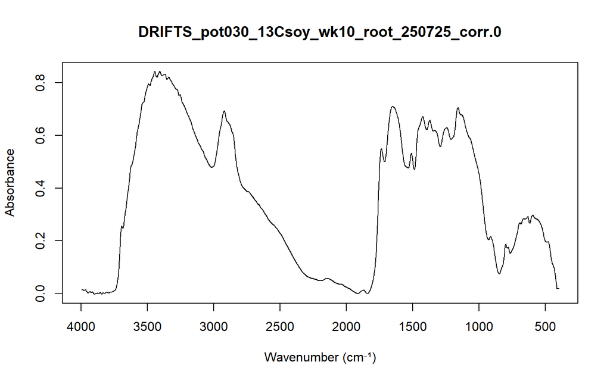

Metadata

| Parameter | Value |
| --- | --- |
| File Name | DRIFTS_pot030_13Csoy_wk10_root_250725_corr.0 |
| Timestamp | 2025-07-25 20:21:37 GMT-7 |
| Max Y | 0.843558788299561 |
| Min Y | -0.00326710939407349 |
| Aperture Setting | 6 mm |
| Scanner Velocity | 10.0S |
| Result Spectrum | AB |
| Resolution | 4 |
| Sample Scans | 400 |
| End Frequency | 400 |
| Start Frequency | 4000 |
| Duration | 364.56689453125 |
| Experiment (method) | SALK_soils_method.xpm |

#### Spectrum 3 : DRIFTS_pot032_13Cwheat_wk0_root_250725_corr.0

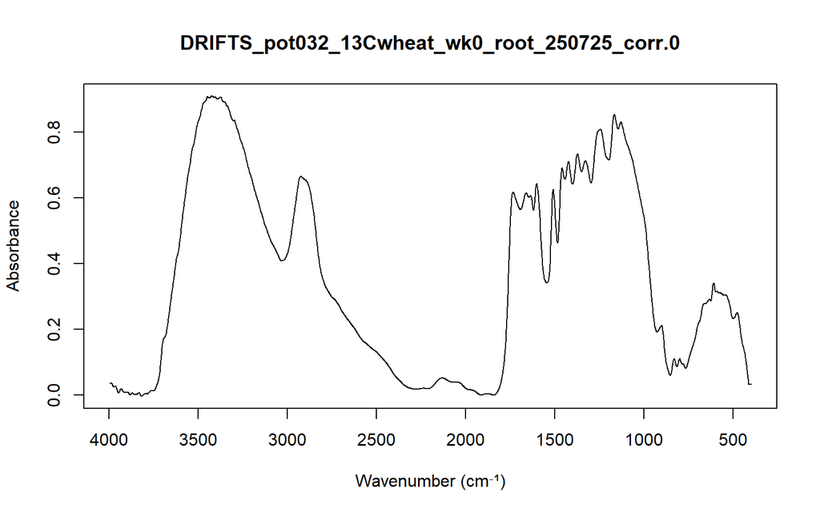

Metadata

| Parameter | Value |
| --- | --- |
| File Name | DRIFTS_pot032_13Cwheat_wk0_root_250725_corr.0 |
| Timestamp | 2025-07-25 20:22:45 GMT-7 |
| Max Y | 0.909599244594574 |
| Min Y | -0.00415003532543778 |
| Aperture Setting | 6 mm |
| Scanner Velocity | 10.0S |
| Result Spectrum | AB |
| Resolution | 4 |
| Sample Scans | 400 |
| End Frequency | 400 |
| Start Frequency | 4000 |
| Duration | 364.56982421875 |
| Experiment (method) | SALK_soils_method.xpm |

#### Spectrum 4 : DRIFTS_pot047_13Crice_wk0_root_250725_corr.0

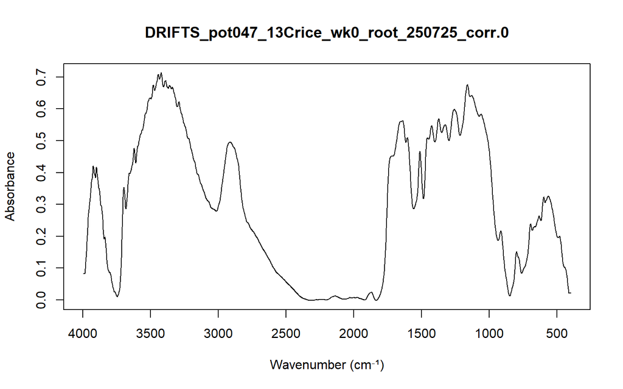

Metadata

| Parameter | Value |
| --- | --- |
| File Name | DRIFTS_pot047_13Crice_wk0_root_250725_corr.0 |
| Timestamp | 2025-07-25 20:23:56 GMT-7 |
| Max Y | 0.712926685810089 |
| Min Y | -0.00133463030215353 |
| Aperture Setting | 6 mm |
| Scanner Velocity | 10.0S |
| Result Spectrum | AB |
| Resolution | 4 |
| Sample Scans | 400 |
| End Frequency | 400 |
| Start Frequency | 4000 |
| Duration | 364.56591796875 |
| Experiment (method) | SALK_soils_method.xpm |

#### Spectrum 5 : DRIFTS_pot053_13Cwheat_wk10_root_250725_corr.0

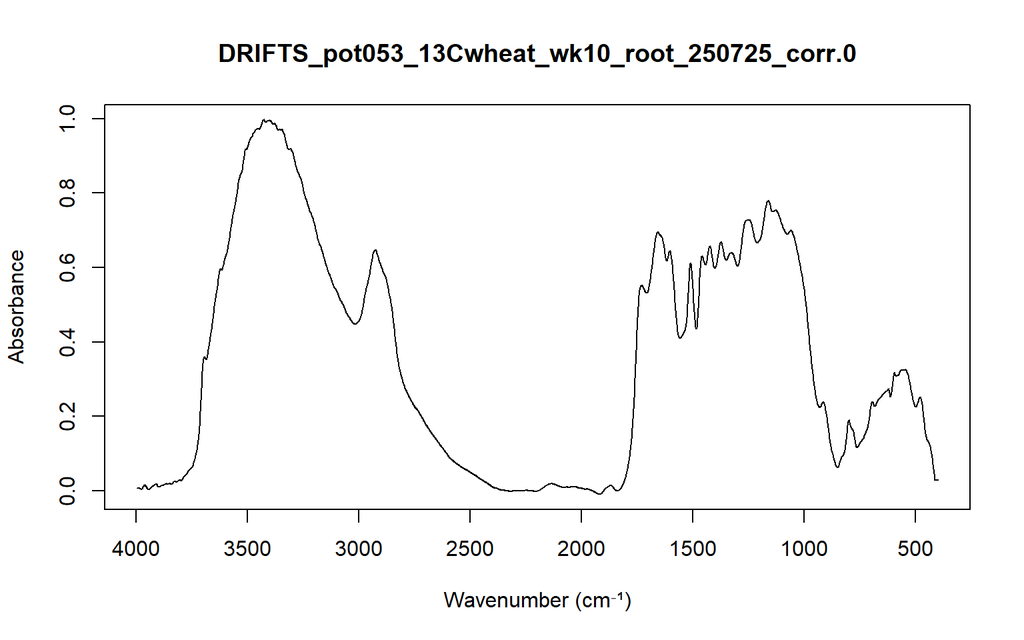

Metadata

| Parameter | Value |
| --- | --- |
| File Name | DRIFTS_pot053_13Cwheat_wk10_root_250725_corr.0 |
| Timestamp | 2025-07-25 20:24:39 GMT-7 |
| Max Y | 0.997280716896057 |
| Min Y | -0.00962971057742834 |
| Aperture Setting | 6 mm |
| Scanner Velocity | 10.0S |
| Result Spectrum | AB |
| Resolution | 4 |
| Sample Scans | 400 |
| End Frequency | 400 |
| Start Frequency | 4000 |
| Duration | 364.56591796875 |
| Experiment (method) | SALK_soils_method.xpm |

#### Spectrum 6 : DRIFTS_pot055_13Crice_wk10_root_250725_corr.0

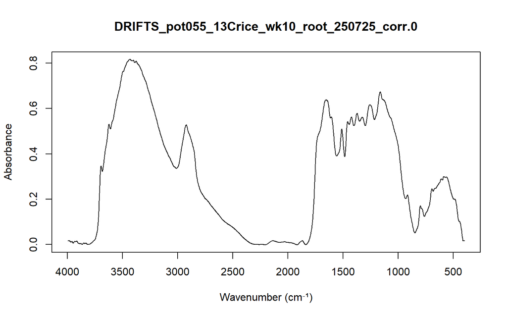

Metadata

| Parameter | Value |
| --- | --- |
| File Name | DRIFTS_pot055_13Crice_wk10_root_250725_corr.0 |
| Timestamp | 2025-07-25 20:26:35 GMT-7 |
| Max Y | 0.816974341869354 |
| Min Y | -0.00123318459372967 |
| Aperture Setting | 6 mm |
| Scanner Velocity | 10.0S |
| Result Spectrum | AB |
| Resolution | 4 |
| Sample Scans | 400 |
| End Frequency | 400 |
| Start Frequency | 4000 |
| Duration | 364.56689453125 |
| Experiment (method) | SALK_soils_method.xpm |

#### Spectrum 7 : DRIFTS_pot055qmark_13Crice_wk10_root_250725_corr.0

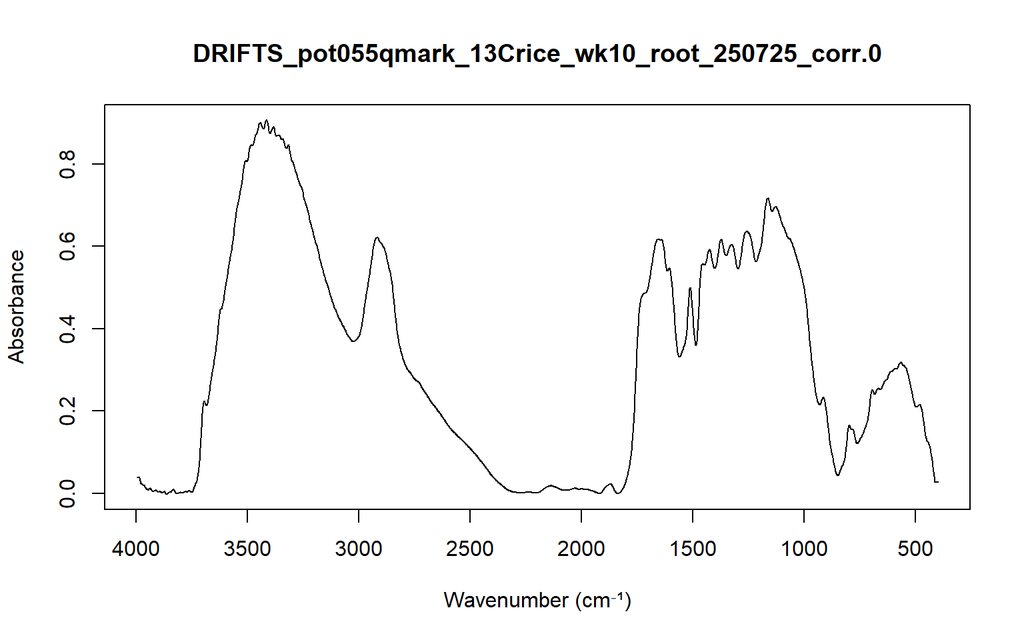

Metadata

| Parameter | Value |
| --- | --- |
| File Name | DRIFTS_pot055qmark_13Crice_wk10_root_250725_corr.0 |
| Timestamp | 2025-07-25 20:25:51 GMT-7 |
| Max Y | 0.907369911670685 |
| Min Y | -0.00234174402430654 |
| Aperture Setting | 6 mm |
| Scanner Velocity | 10.0S |
| Result Spectrum | AB |
| Resolution | 4 |
| Sample Scans | 400 |
| End Frequency | 400 |
| Start Frequency | 4000 |
| Duration | 364.56591796875 |
| Experiment (method) | SALK_soils_method.xpm |

#### Spectrum 8 : DRIFTS_pot062_13Csoy_wk0_root_250725_corr.0

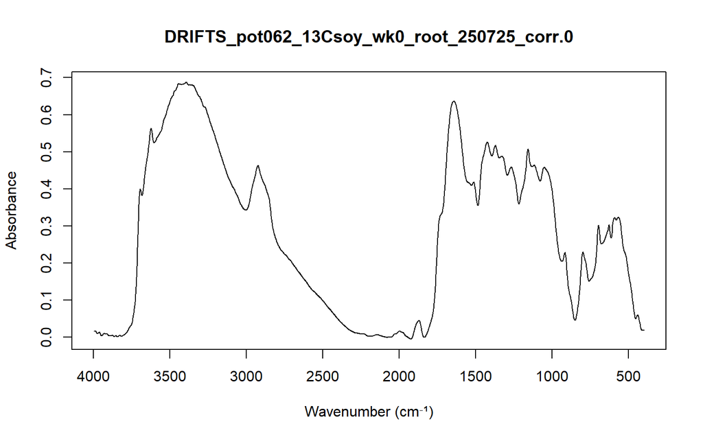

Metadata

| Parameter | Value |
| --- | --- |
| File Name | DRIFTS_pot062_13Csoy_wk0_root_250725_corr.0 |
| Timestamp | 2025-07-25 20:27:28 GMT-7 |
| Max Y | 0.687717080116272 |
| Min Y | -0.00538174575194716 |
| Aperture Setting | 6 mm |
| Scanner Velocity | 10.0S |
| Result Spectrum | AB |
| Resolution | 4 |
| Sample Scans | 400 |
| End Frequency | 400 |
| Start Frequency | 4000 |
| Duration | 364.56884765625 |
| Experiment (method) | SALK_soils_method.xpm |

#### Spectrum 9 : DRIFTS_pot079_13Crice_wk0_root_250725_corr.0

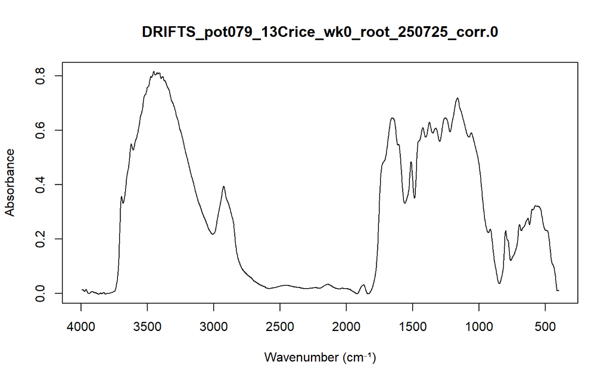

Metadata

| Parameter | Value |
| --- | --- |
| File Name | DRIFTS_pot079_13Crice_wk0_root_250725_corr.0 |
| Timestamp | 2025-07-25 20:28:00 GMT-7 |
| Max Y | 0.816869914531708 |
| Min Y | -0.00257659493945539 |
| Aperture Setting | 6 mm |
| Scanner Velocity | 10.0S |
| Result Spectrum | AB |
| Resolution | 4 |
| Sample Scans | 400 |
| End Frequency | 400 |
| Start Frequency | 4000 |
| Duration | 364.56787109375 |
| Experiment (method) | SALK_soils_method.xpm |

#### Spectrum 10 : DRIFTS_pot080_13Csoy_wk10_root_250725_corr.0

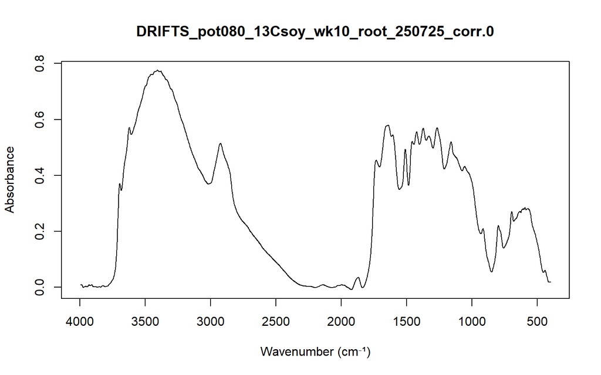

Metadata

| Parameter | Value |
| --- | --- |
| File Name | DRIFTS_pot080_13Csoy_wk10_root_250725_corr.0 |
| Timestamp | 2025-07-25 20:28:56 GMT-7 |
| Max Y | 0.77625048160553 |
| Min Y | -0.00814440380781889 |
| Aperture Setting | 6 mm |
| Scanner Velocity | 10.0S |
| Result Spectrum | AB |
| Resolution | 4 |
| Sample Scans | 400 |
| End Frequency | 400 |
| Start Frequency | 4000 |
| Duration | 364.56689453125 |
| Experiment (method) | SALK_soils_method.xpm |

#### Spectrum 11 : DRIFTS_pot094_13Csoy_wk10_root_250725_corr.0

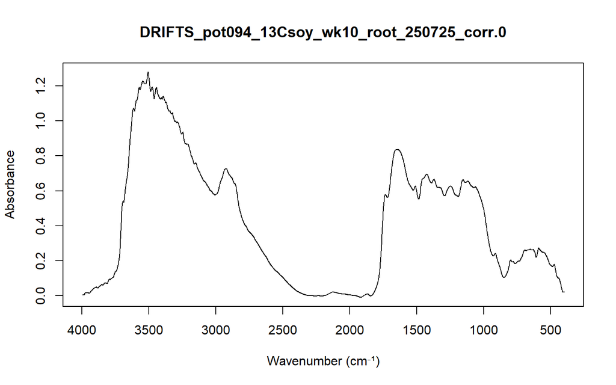

Metadata

| Parameter | Value |
| --- | --- |
| File Name | DRIFTS_pot094_13Csoy_wk10_root_250725_corr.0 |
| Timestamp | 2025-07-25 20:29:09 GMT-7 |
| Max Y | 1.27848649024963 |
| Min Y | -0.00875786785036325 |
| Aperture Setting | 6 mm |
| Scanner Velocity | 10.0S |
| Result Spectrum | AB |
| Resolution | 4 |
| Sample Scans | 400 |
| End Frequency | 400 |
| Start Frequency | 4000 |
| Duration | 364.56689453125 |
| Experiment (method) | SALK_soils_method.xpm |

#### Spectrum 12 : DRIFTS_pot094_13Csoy_wk10_soil_250630_corr.0

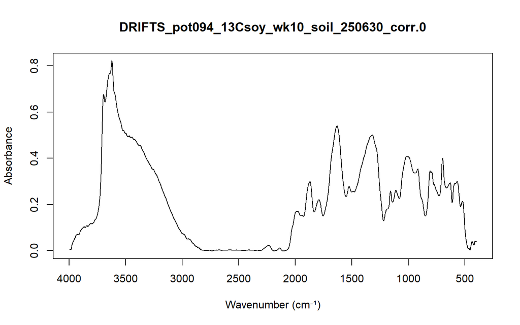

Metadata

| Parameter | Value |
| --- | --- |
| File Name | DRIFTS_pot094_13Csoy_wk10_soil_250630_corr.0 |
| Timestamp | 2025-07-25 20:46:03 GMT-7 |
| Max Y | 0.821687042713165 |
| Min Y | -0.00153941253665835 |
| Aperture Setting | 6 mm |
| Scanner Velocity | 10.0S |
| Result Spectrum | AB |
| Resolution | 4 |
| Sample Scans | 400 |
| End Frequency | 400 |
| Start Frequency | 4000 |
| Duration | 364.454833984375 |
| Experiment (method) | SALK_soils_method.xpm |

#### Spectrum 13 : DRIFTS_pot103_13Crice_wk0_root_recNMR_250725_corr.0

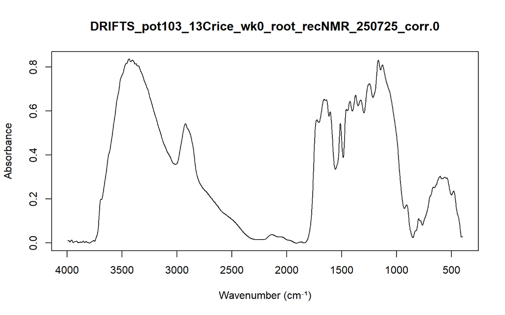

Metadata

| Parameter | Value |
| --- | --- |
| File Name | DRIFTS_pot103_13Crice_wk0_root_recNMR_250725_corr.0 |
| Timestamp | 2025-07-25 20:30:32 GMT-7 |
| Max Y | 0.836920917034149 |
| Min Y | -0.00138377456460148 |
| Aperture Setting | 6 mm |
| Scanner Velocity | 10.0S |
| Result Spectrum | AB |
| Resolution | 4 |
| Sample Scans | 400 |
| End Frequency | 400 |
| Start Frequency | 4000 |
| Duration | 364.56982421875 |
| Experiment (method) | SALK_soils_method.xpm |

#### Spectrum 14 : DRIFTS_pot103_13Crice_wk0_root_vial1_250725_corr.0

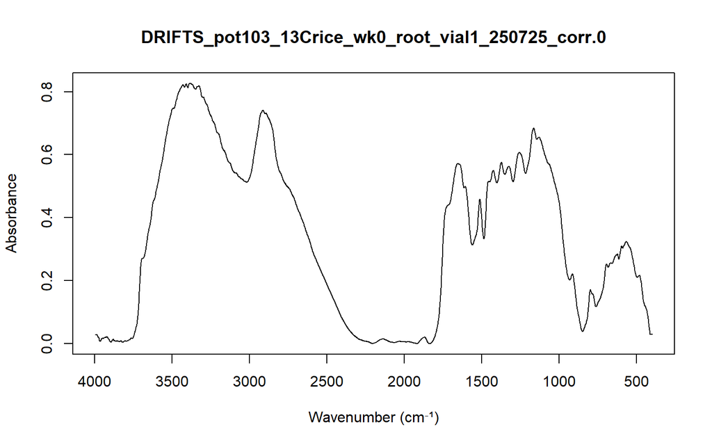

Metadata

| Parameter | Value |
| --- | --- |
| File Name | DRIFTS_pot103_13Crice_wk0_root_vial1_250725_corr.0 |
| Timestamp | 2025-07-25 20:30:55 GMT-7 |
| Max Y | 0.826825261116028 |
| Min Y | -0.000596170837525278 |
| Aperture Setting | 6 mm |
| Scanner Velocity | 10.0S |
| Result Spectrum | AB |
| Resolution | 4 |
| Sample Scans | 400 |
| End Frequency | 400 |
| Start Frequency | 4000 |
| Duration | 364.56787109375 |
| Experiment (method) | SALK_soils_method.xpm |

#### Spectrum 15 : DRIFTS_pot103_13Crice_wk0_root_vial2_250725_corr.0

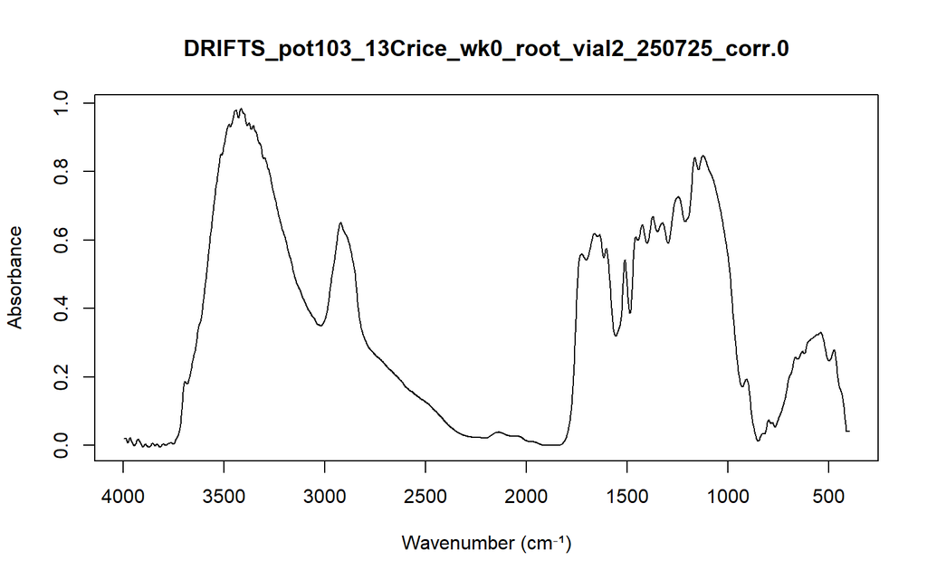

Metadata

| Parameter | Value |
| --- | --- |
| File Name | DRIFTS_pot103_13Crice_wk0_root_vial2_250725_corr.0 |
| Timestamp | 2025-07-25 20:31:26 GMT-7 |
| Max Y | 0.984898567199707 |
| Min Y | -0.00565983727574348 |
| Aperture Setting | 6 mm |
| Scanner Velocity | 10.0S |
| Result Spectrum | AB |
| Resolution | 4 |
| Sample Scans | 400 |
| End Frequency | 400 |
| Start Frequency | 4000 |
| Duration | 364.56591796875 |
| Experiment (method) | SALK_soils_method.xpm |

#### Spectrum 16 : DRIFTS_pot103_13Crice_wk0_root_vial3_250725_corr.0

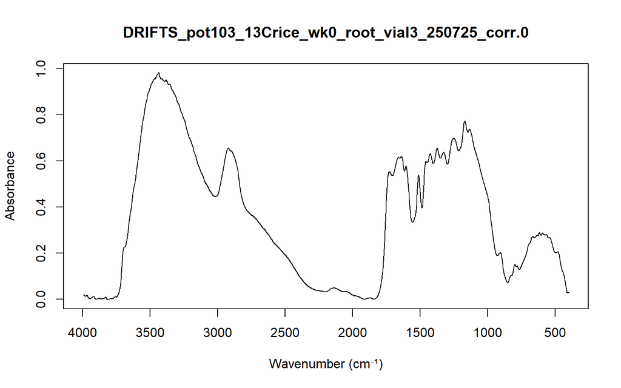

Metadata

| Parameter | Value |
| --- | --- |
| File Name | DRIFTS_pot103_13Crice_wk0_root_vial3_250725_corr.0 |
| Timestamp | 2025-07-25 20:31:46 GMT-7 |
| Max Y | 0.983739078044891 |
| Min Y | -0.0026757272426039 |
| Aperture Setting | 6 mm |
| Scanner Velocity | 10.0S |
| Result Spectrum | AB |
| Resolution | 4 |
| Sample Scans | 400 |
| End Frequency | 400 |
| Start Frequency | 4000 |
| Duration | 364.56591796875 |
| Experiment (method) | SALK_soils_method.xpm |

#### Spectrum 17 : DRIFTS_pot107_12Crice_wk0_root_really13_250725_corr.0

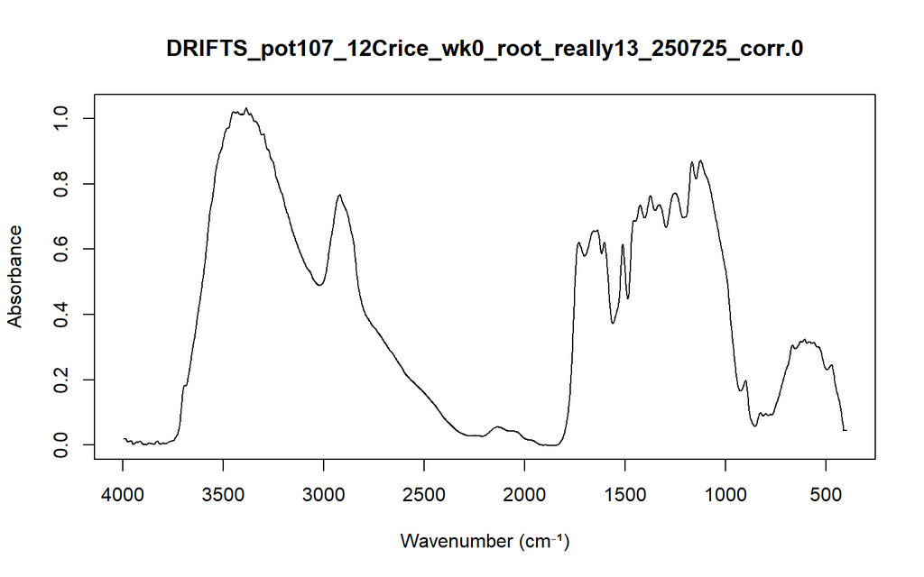

Metadata

| Parameter | Value |
| --- | --- |
| File Name | DRIFTS_pot107_12Crice_wk0_root_really13_250725_corr.0 |
| Timestamp | 2025-07-25 20:32:00 GMT-7 |
| Max Y | 1.03206670284271 |
| Min Y | -0.00172662467230111 |
| Aperture Setting | 6 mm |
| Scanner Velocity | 10.0S |
| Result Spectrum | AB |
| Resolution | 4 |
| Sample Scans | 400 |
| End Frequency | 400 |
| Start Frequency | 4000 |
| Duration | 364.56591796875 |
| Experiment (method) | SALK_soils_method.xpm |

## Stacking multiple spectra

### Stacking re-runs

This code looks for files with the same sample number and stacks their spectra, to check whether reruns are consistent.

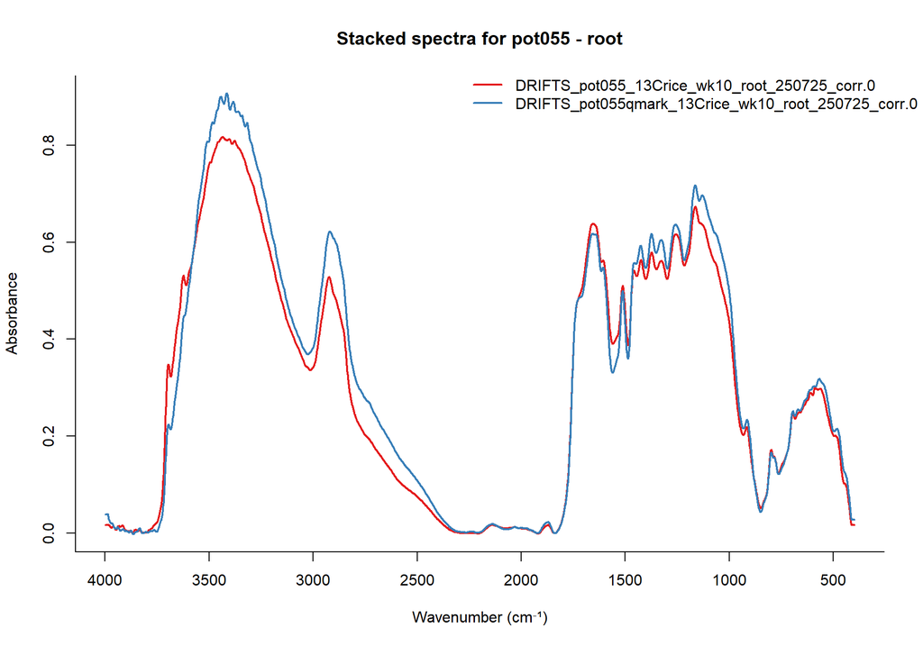

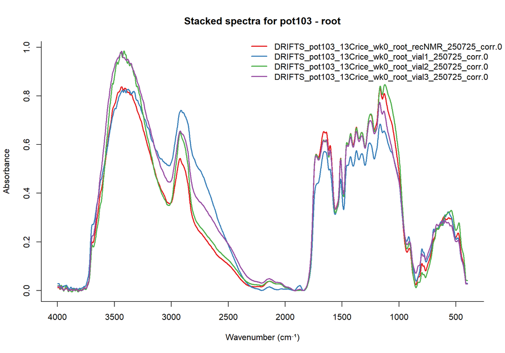

```r
knitr::opts_chunk$set(
  collapse = TRUE,
  comment = "#>",
  echo = TRUE,
  results = "markup",
  include = TRUE
)
library(opusreader2)
library(RColorBrewer)

#save the path to your corrected spectra
# # Mac path
# corr_spectra <- "/Users/adrianneseiden/Library/CloudStorage/Box-Box/Salk Institute Project/AKS Salk files/Adrianne_FTIRdata/Corrected_files" # nolint
#  # Windows path
# corr_spectra <- "C:/Users/adria/Box/Box-Box/Salk Institute Project/AKS Salk files/Adrianne_FTIRdata/Corrected_files" # nolint
# Relative path
corr_spectra <- "../Adrianne_FTIRdata/Corrected_files"

data_test <- read_opus(dsn = corr_spectra)

# Helper to extract sample number from filename (e.g., "pot094")
extract_sample_number <- function(filename) {
  m <- regexpr("[a-z]{3}[0-9]+", filename)
  if (m[1] != -1) {
    regmatches(filename, m)
  } else {
    NA
  }
}

# Helper to extract sample type (e.g.,"soil", "root")
extract_sample_type <- function(filename) {
  m <- regexpr("soil|root", filename, ignore.case = TRUE)
  if (m[1] != -1) {
    tolower(regmatches(filename, m))
  } else {
    NA
  }
}

# Group files by sample number & sample type
sample_numbers <- sapply(names(data_test), extract_sample_number)
sample_types <- sapply(names(data_test), extract_sample_type)

# Create unique combinations of sample number and sample type
sample_combinations <- paste(sample_numbers, sample_types, sep = "_")
unique_combinations <- unique(sample_combinations[!is.na(sample_numbers)
                                                  & !is.na(sample_types)])

# Plot stacked spectra for each unique combination
library(RColorBrewer)
for (combination in unique_combinations) {
  idx <- which(sample_combinations == combination)
  if (length(idx) > 1) {
    # Extract sample number and type from combination
    parts <- strsplit(combination, "_")[[1]]
    sample_num <- parts[1]
    sample_type <- parts[2]

    spectra <- data_test[idx]
    colors <- brewer.pal(min(length(spectra), 8), "Set1")
    plot(NULL, xlim = rev(range(spectra[[1]]$ab$wavenumbers)),
         ylim = range(sapply(spectra, function(x) x$ab$data), na.rm = TRUE),
         xlab = "Wavenumber (cm⁻¹)", ylab = "Absorbance",
         main = paste("Stacked spectra for", sample_num, "-", sample_type),
         bty = "l")
    for (i in seq_along(spectra)) {
      ab_data <- spectra[[i]]$ab
      if (!is.null(ab_data) && !is.null(ab_data$wavenumbers) &&
            !is.null(ab_data$data)) {
        lines(ab_data$wavenumbers, ab_data$data, col = colors[i], lwd = 2)
      }
    }
    legend("topright",
           inset = c(-0.05, -0.02),
           legend = names(spectra),
           col = colors[seq_along(spectra)],
           lwd = 2,
           xpd = TRUE,
           bty = "n")
  }
}
```

### Stacking by crop & time

This code stacks spectra of the same crop and timepoint.

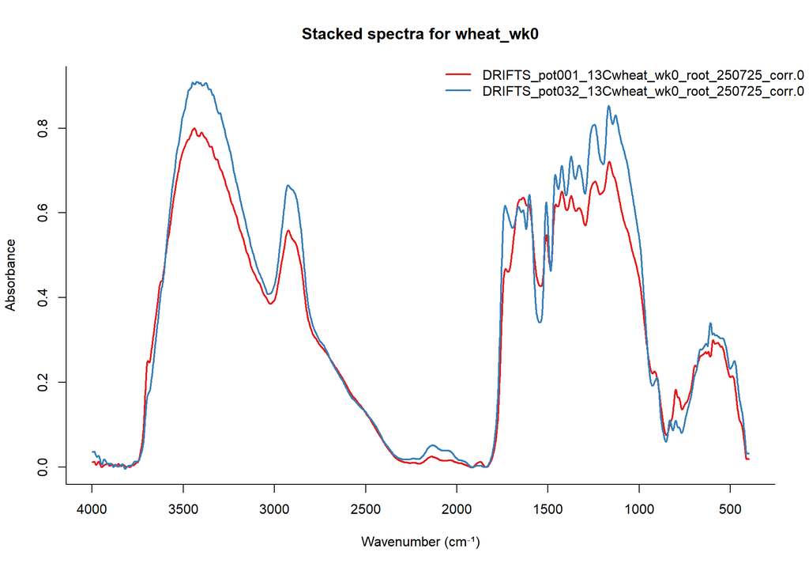

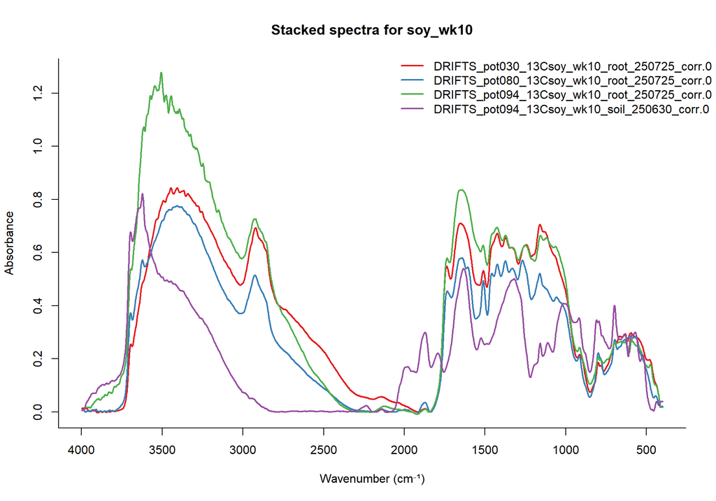

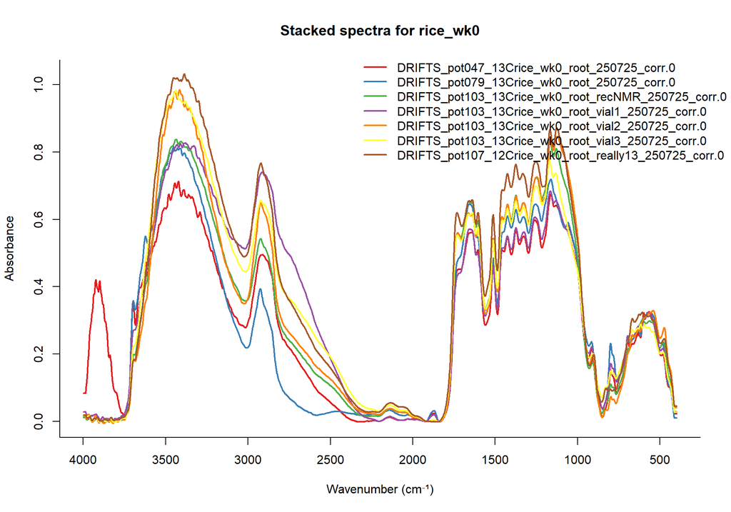

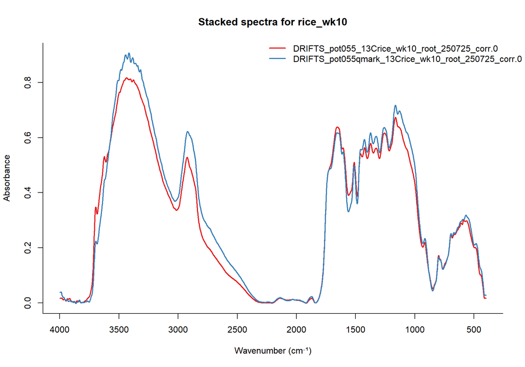

```r
knitr::opts_chunk$set(
  collapse = TRUE,
  comment = "#>",
  echo = TRUE,
  results = "markup",
  include = TRUE
)
# Helper functions to extract crop and timepoint from filename
extract_crop <- function(filename) {
  m <- regexpr("rice|wheat|soy", filename, ignore.case = TRUE)
  if (m[1] != -1) tolower(regmatches(filename, m)) else NA
}
extract_time <- function(filename) {
  m <- regexpr("wk[0-9]+", filename, ignore.case = TRUE)
  if (m[1] != -1) tolower(regmatches(filename, m)) else NA
}

# Get crop and time for each file
crops <- sapply(names(data_test), extract_crop)
times <- sapply(names(data_test), extract_time)

# Unique crop-time combinations
combos <- na.omit(unique(paste(crops, times, sep = "_")))

library(RColorBrewer)
for (combo in combos) {
  idx <- which(paste(crops, times, sep = "_") == combo)
  if (length(idx) > 1) {
    spectra <- data_test[idx]
    colors <- brewer.pal(min(length(spectra), 8), "Set1")
    plot(NULL, xlim = rev(range(spectra[[1]]$ab$wavenumbers)),
         ylim = range(sapply(spectra, function(x) x$ab$data), na.rm = TRUE),
         xlab = "Wavenumber (cm⁻¹)", ylab = "Absorbance",
         main = paste("Stacked spectra for", combo),
         bty = "l")
    for (i in seq_along(spectra)) {
      ab_data <- spectra[[i]]$ab
      if (!is.null(ab_data) &&
            !is.null(ab_data$wavenumbers)
          && !is.null(ab_data$data)) {
        lines(ab_data$wavenumbers, ab_data$data, col = colors[i], lwd = 2)
      }
    }
    legend("topright",
           inset = c(-0.05, -0.02),
           legend = names(spectra),
           col = colors[seq_along(spectra)],
           lwd = 2,
           xpd = TRUE,
           bty = "n")
  }
}
```

# Reading DPT files

This code is modified from code by Stephany Soledad Chacon, “Box> Salk Institute Project> Salk Data> FTIR_Intact_decomposition_pots> FTIR_analysis.Rmd”. Using data in the DPT format, we can extrapolate sample attributes from the file names, then normalize and visualize spectra across replicates, crops, and timepoints. The width of the line bounding the spectra represents the range of the data.

## Importing FTIR data using readr

### Define file path and import multiple files into one data frame

```
#> Files found in directory:
#>  [1] "DRIFTS_KBr250630_400scans1.0.dpt"
#>  [2] "DRIFTS_pot001_13Cwheat_wk0_root_250725.0.dpt"
#>  [3] "DRIFTS_pot030_13Csoy_wk10_root_250725.0.dpt"
#>  [4] "DRIFTS_pot032_13Cwheat_wk0_root_250725.0.dpt"
#>  [5] "DRIFTS_pot047_13Crice_wk0_root_250725.0.dpt"
#>  [6] "DRIFTS_pot053_13Cwheat_wk10_root_250725.0.dpt"
#>  [7] "DRIFTS_pot055_13Crice_wk10_root_250725.0.dpt"
#>  [8] "DRIFTS_pot055_13Crice_wk10_root_qmark_250725.0.dpt"
#>  [9] "DRIFTS_pot062_13Csoy_wk0_root_250725.0.dpt"
#> [10] "DRIFTS_pot079_13Crice_wk0_root_250725.0.dpt"
#> [11] "DRIFTS_pot080_13Csoy_wk10_root_250725.0.dpt"
#> [12] "DRIFTS_pot094_13Csoy_wk10_root_250725.0.dpt"
#> [13] "DRIFTS_pot094_13Csoy_wk10_soil_250630.0.dpt"
#> [14] "DRIFTS_pot103_13Crice_wk0_root_recNMR_250725.0.dpt"
#> [15] "DRIFTS_pot103_13Crice_wk0_root_vial1_250725.0.dpt"
#> [16] "DRIFTS_pot103_13Crice_wk0_root_vial2_250725.2.dpt"
#> [17] "DRIFTS_pot103_13Crice_wk0_root_vial3_250725.0.dpt"
#> [18] "DRIFTS_pot107_12Crice_wk0_root_really13_250725.0.dpt"
#> Number of .dpt files: 18
```

### Extract sample info from filename

Using the long format dataframe `dpt_data` **format example: DRIFTS_pot094_13Csoy_wk10_soil_250630.0.dpt**

```
#> Column filenames: wavenumber absorbance filename
#> [1] "pot"
#>  [1] "001" "030" "032" "047" "053" "055" "062" "079" "080" "094" "103" "107"
#> [1] 13 12
#> [1] "wheat" "soy"   "rice"
#> [1] "wk0"  "wk10"
#> [1] "root" "soil"
#> [1] "250725" "250630"
#> [1] NA         "qmark"    "recNMR"   "vial1"    "vial2"    "vial3"    "really13"
#> # A tibble: 6 × 11
#>   wavenumber absorbance filename      source ID    isotope crop  timepoint type
#>        <dbl>      <dbl> <chr>         <chr>  <chr>   <dbl> <chr> <chr>     <chr>
#> 1      3998.     0.0115 DRIFTS_pot00… pot    001        13 wheat wk0       root
#> 2      3997.     0.0115 DRIFTS_pot00… pot    001        13 wheat wk0       root
#> 3      3995.     0.0115 DRIFTS_pot00… pot    001        13 wheat wk0       root
#> 4      3994.     0.0115 DRIFTS_pot00… pot    001        13 wheat wk0       root
#> 5      3993.     0.0115 DRIFTS_pot00… pot    001        13 wheat wk0       root
#> 6      3991.     0.0115 DRIFTS_pot00… pot    001        13 wheat wk0       root
#> # ℹ 2 more variables: run_date <chr>, notes <chr>
```

## Plotting by timepoint and type

### Week 0

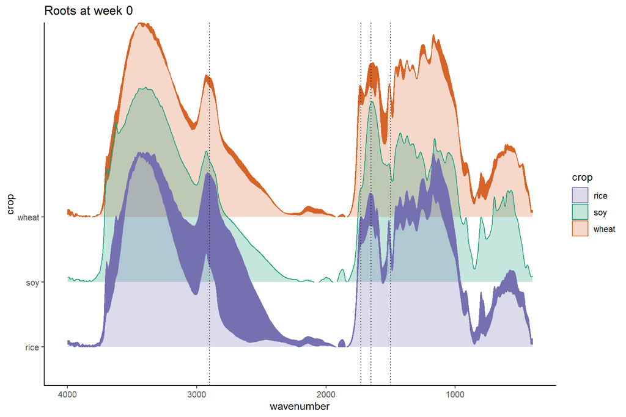

```
FALSE [1] "001" "032" "062" "079" "103" "107"
```

### Week 10

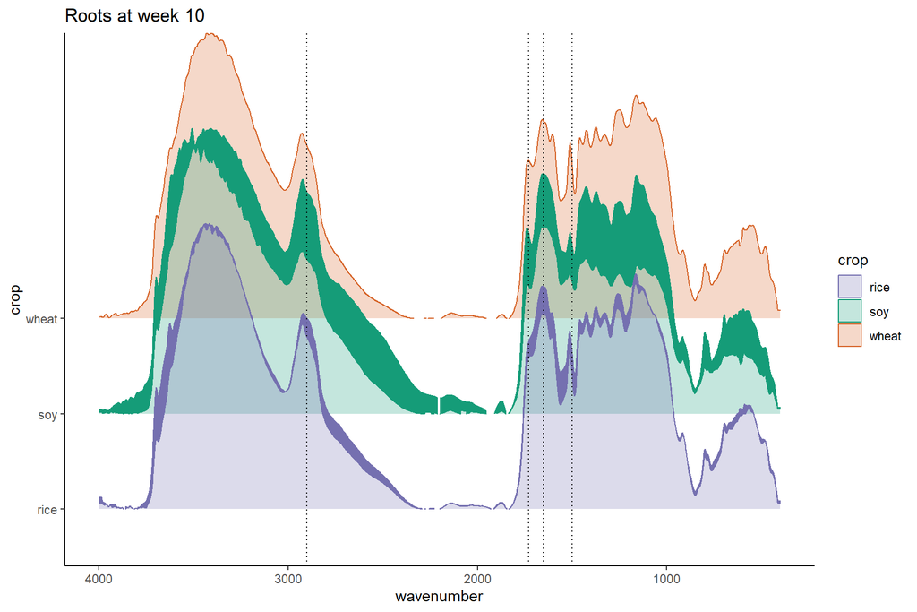

```
#> [1] "030" "053" "055" "080" "094"
```

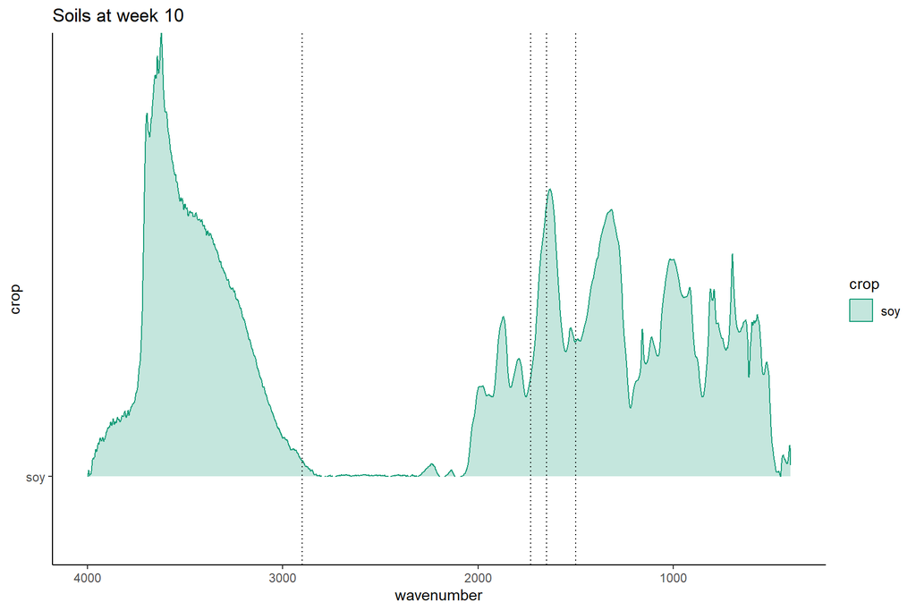

```
#> [1] "094"
```

## Plotting by crop

### wheat roots

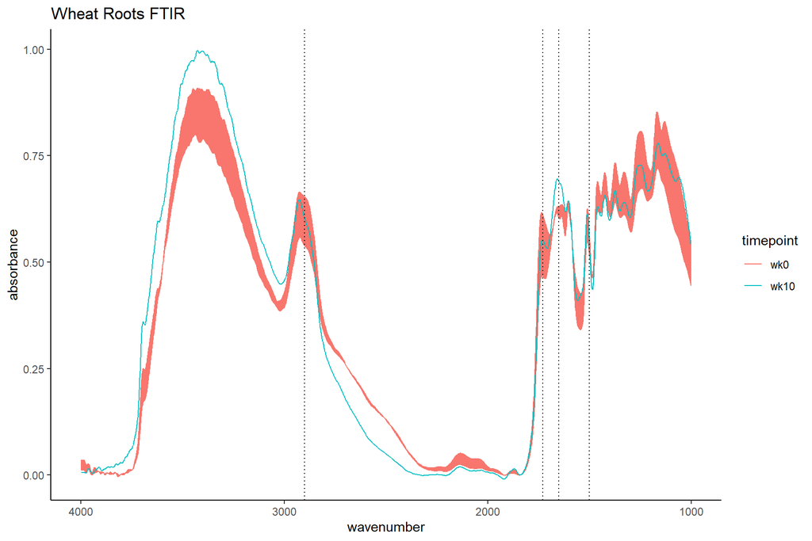

```
#> [1] "001" "032" "053"
```

### rice roots

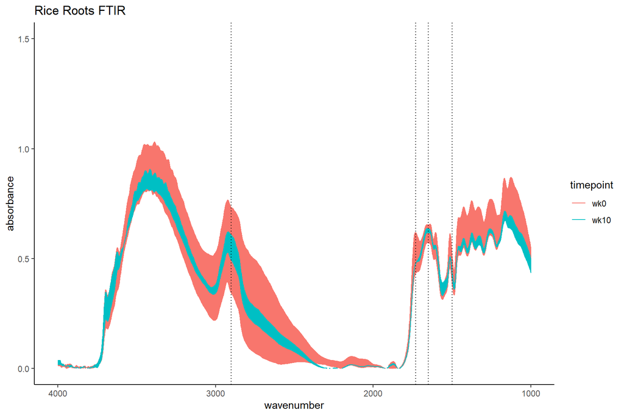

```
#> [1] "055" "079" "103" "107"
```

### soy roots

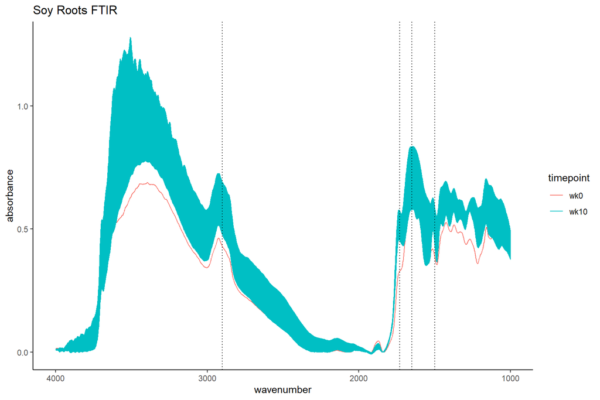

```
#> [1] "030" "062" "080" "094"
```